# Regression model for Bike-Sharing dataset

```python
import numpy as np
import pandas as pd
import matplotlib.pyplot as plt
import seaborn as sns

import sklearn
from sklearn.model_selection import train_test_split
from sklearn.preprocessing import MinMaxScaler

import statsmodels.api as sm
# Check for the VIF values of the feature variables.
from statsmodels.stats.outliers_influence import variance_inflation_factor

from sklearn.linear_model import LinearRegression
from sklearn.feature_selection import RFE
from sklearn.metrics import r2_score,mean_squared_error

import warnings
warnings.filterwarnings('ignore')
```

```python
df = pd.read_csv('day.csv')
df
```

|  | instant | dteday | season | yr | mnth | holiday | weekday | workingday | weathersit | temp | atemp | hum | windspeed | casual | registered | cnt |
| --- | --- | --- | --- | --- | --- | --- | --- | --- | --- | --- | --- | --- | --- | --- | --- | --- |
| 0 | 1 | 01-01-2018 | 1 | 0 | 1 | 0 | 6 | 0 | 2 | 14.110847 | 18.18125 | 80.5833 | 10.749882 | 331 | 654 | 985 |
| 1 | 2 | 02-01-2018 | 1 | 0 | 1 | 0 | 0 | 0 | 2 | 14.902598 | 17.68695 | 69.6087 | 16.652113 | 131 | 670 | 801 |
| 2 | 3 | 03-01-2018 | 1 | 0 | 1 | 0 | 1 | 1 | 1 | 8.050924 | 9.47025 | 43.7273 | 16.636703 | 120 | 1229 | 1349 |
| 3 | 4 | 04-01-2018 | 1 | 0 | 1 | 0 | 2 | 1 | 1 | 8.200000 | 10.60610 | 59.0435 | 10.739832 | 108 | 1454 | 1562 |
| 4 | 5 | 05-01-2018 | 1 | 0 | 1 | 0 | 3 | 1 | 1 | 9.305237 | 11.46350 | 43.6957 | 12.522300 | 82 | 1518 | 1600 |
| ... | ... | ... | ... | ... | ... | ... | ... | ... | ... | ... | ... | ... | ... | ... | ... | ... |
| 725 | 726 | 27-12-2019 | 1 | 1 | 12 | 0 | 4 | 1 | 2 | 10.420847 | 11.33210 | 65.2917 | 23.458911 | 247 | 1867 | 2114 |
| 726 | 727 | 28-12-2019 | 1 | 1 | 12 | 0 | 5 | 1 | 2 | 10.386653 | 12.75230 | 59.0000 | 10.416557 | 644 | 2451 | 3095 |
| 727 | 728 | 29-12-2019 | 1 | 1 | 12 | 0 | 6 | 0 | 2 | 10.386653 | 12.12000 | 75.2917 | 8.333661 | 159 | 1182 | 1341 |
| 728 | 729 | 30-12-2019 | 1 | 1 | 12 | 0 | 0 | 0 | 1 | 10.489153 | 11.58500 | 48.3333 | 23.500518 | 364 | 1432 | 1796 |
| 729 | 730 | 31-12-2019 | 1 | 1 | 12 | 0 | 1 | 1 | 2 | 8.849153 | 11.17435 | 57.7500 | 10.374682 | 439 | 2290 | 2729 |

730 rows × 16 columns

```python
df.info()
```

```
<class 'pandas.core.frame.DataFrame'>
RangeIndex: 730 entries, 0 to 729
Data columns (total 16 columns):
 #   Column      Non-Null Count  Dtype
---  ------      --------------  -----
 0   instant     730 non-null    int64
 1   dteday      730 non-null    object
 2   season      730 non-null    int64
 3   yr          730 non-null    int64
 4   mnth        730 non-null    int64
 5   holiday     730 non-null    int64
 6   weekday     730 non-null    int64
 7   workingday  730 non-null    int64
 8   weathersit  730 non-null    int64
 9   temp        730 non-null    float64
 10  atemp       730 non-null    float64
 11  hum         730 non-null    float64
 12  windspeed   730 non-null    float64
 13  casual      730 non-null    int64
 14  registered  730 non-null    int64
 15  cnt         730 non-null    int64
dtypes: float64(4), int64(11), object(1)
memory usage: 91.4+ KB
```

**Observation**

1. We see that the target variable is numerical; that means we can apply regression to predict target variable.  
2. All predictor variables are also numrical or categorical.  
3. We will drop the column `dteday`, as it is not numerical, and would not contribute in predictopm

```python
df = df.drop(columns=['dteday'])
```

```python
df.shape
```

```
(730, 15)
```

```python
df.describe()
```

|  | instant | season | yr | mnth | holiday | weekday | workingday | weathersit | temp | atemp | hum | windspeed | casual | registered | cnt |
| --- | --- | --- | --- | --- | --- | --- | --- | --- | --- | --- | --- | --- | --- | --- | --- |
| count | 730.000000 | 730.000000 | 730.000000 | 730.000000 | 730.000000 | 730.000000 | 730.000000 | 730.000000 | 730.000000 | 730.000000 | 730.000000 | 730.000000 | 730.000000 | 730.000000 | 730.000000 |
| mean | 365.500000 | 2.498630 | 0.500000 | 6.526027 | 0.028767 | 2.997260 | 0.683562 | 1.394521 | 20.319259 | 23.726322 | 62.765175 | 12.763620 | 849.249315 | 3658.757534 | 4508.006849 |
| std | 210.877136 | 1.110184 | 0.500343 | 3.450215 | 0.167266 | 2.006161 | 0.465405 | 0.544807 | 7.506729 | 8.150308 | 14.237589 | 5.195841 | 686.479875 | 1559.758728 | 1936.011647 |
| min | 1.000000 | 1.000000 | 0.000000 | 1.000000 | 0.000000 | 0.000000 | 0.000000 | 1.000000 | 2.424346 | 3.953480 | 0.000000 | 1.500244 | 2.000000 | 20.000000 | 22.000000 |
| 25% | 183.250000 | 2.000000 | 0.000000 | 4.000000 | 0.000000 | 1.000000 | 0.000000 | 1.000000 | 13.811885 | 16.889713 | 52.000000 | 9.041650 | 316.250000 | 2502.250000 | 3169.750000 |
| 50% | 365.500000 | 3.000000 | 0.500000 | 7.000000 | 0.000000 | 3.000000 | 1.000000 | 1.000000 | 20.465826 | 24.368225 | 62.625000 | 12.125325 | 717.000000 | 3664.500000 | 4548.500000 |
| 75% | 547.750000 | 3.000000 | 1.000000 | 10.000000 | 0.000000 | 5.000000 | 1.000000 | 2.000000 | 26.880615 | 30.445775 | 72.989575 | 15.625589 | 1096.500000 | 4783.250000 | 5966.000000 |
| max | 730.000000 | 4.000000 | 1.000000 | 12.000000 | 1.000000 | 6.000000 | 1.000000 | 3.000000 | 35.328347 | 42.044800 | 97.250000 | 34.000021 | 3410.000000 | 6946.000000 | 8714.000000 |

Now, we will visualize numerical variables. As a part of which, we want to do two things:  
1. We want to check if linear regression model makes sense or not; i.e. price should be in some way be linearly related to atleast some variables  
2. We want to see if variables are collinear; i,e. validate multicollinearity

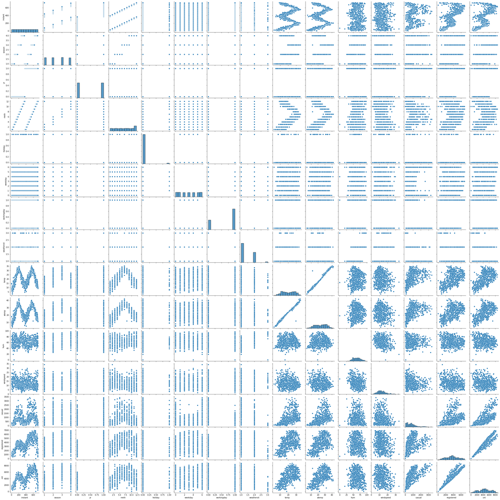

```python
sns.pairplot(df)
plt.show()
```

**Observation**  
From the pairplot, we see that:  
1. The column `cnt` and "temp and atemp" show some positive correlation b/w each other; i.e. "some variance" in `cnt` variable can be explained by variance in "temp and atemp". This means that we can go ahead with regression model.  
Next we will visualize categorical variables.

Also sharing definitions of categorical variables:

1. season : season (1:spring, 2:summer, 3:fall, 4:winter)
2. mnth : month ( 1 to 12)
3. holiday : weather day is a holiday or not (extracted from http://dchr.dc.gov/page/holiday-schedule)
4. weekday : day of the week
5. workingday : if day is neither weekend nor holiday is 1, otherwise is 0.
6. weathersit :

   ```
    - 1: Clear, Few clouds, Partly cloudy, Partly cloudy
    - 2: Mist + Cloudy, Mist + Broken clouds, Mist + Few clouds, Mist
    - 3: Light Snow, Light Rain + Thunderstorm + Scattered clouds, Light Rain + Scattered clouds
    - 4: Heavy Rain + Ice Pallets + Thunderstorm + Mist, Snow + Fog
   ```

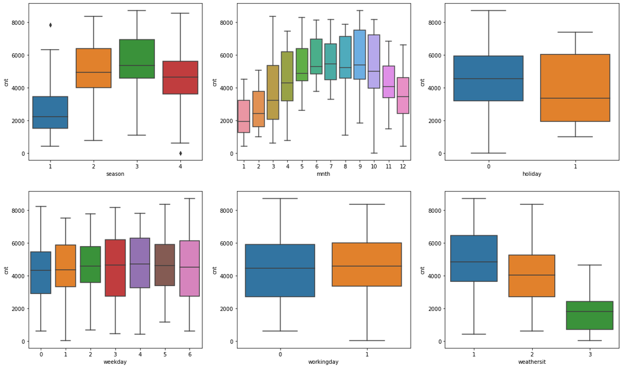

```python
plt.figure(figsize = (20,12))
plt.subplot(2,3,1)
sns.boxplot(y='cnt', x='season', data=df)

plt.subplot(2,3,2)
sns.boxplot(y='cnt', x='mnth', data=df)

plt.subplot(2,3,3)
sns.boxplot(y='cnt', x='holiday', data=df)

plt.subplot(2,3,6)
sns.boxplot(y='cnt', x='weathersit', data=df)

plt.subplot(2,3,5)
sns.boxplot(y='cnt', x='workingday', data=df)

plt.subplot(2,3,4)
sns.boxplot(y='cnt', x='weekday', data=df)


plt.show()
```

**Observation**  
We can also visualise some of these categorical features parallely by using the `hue` argument. Below is the plot for `season` with `workingday` as the hue.

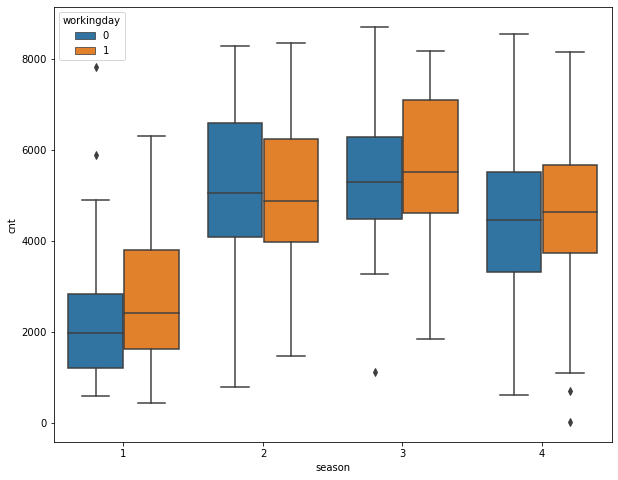

```python
plt.figure(figsize = (10,8))

sns.boxplot(x='season', y='cnt', hue='workingday' ,data=df)
plt.show()
```

**Observation**  
1. We see that a number of columns such as season, weather, mnth and weekday are representated using numbers, when text description would have been helpful.  
2. Hence, we will map values of these columns to something meaningful.

### Creating dummy variables

```python
# Replacing values of column season
df.season.replace({1:"spring", 2:"summer", 3:"fall", 4:"winter"},inplace = True)

df.head()
```

|  | instant | season | yr | mnth | holiday | weekday | workingday | weathersit | temp | atemp | hum | windspeed | casual | registered | cnt |
| --- | --- | --- | --- | --- | --- | --- | --- | --- | --- | --- | --- | --- | --- | --- | --- |
| 0 | 1 | spring | 0 | 1 | 0 | 6 | 0 | 2 | 14.110847 | 18.18125 | 80.5833 | 10.749882 | 331 | 654 | 985 |
| 1 | 2 | spring | 0 | 1 | 0 | 0 | 0 | 2 | 14.902598 | 17.68695 | 69.6087 | 16.652113 | 131 | 670 | 801 |
| 2 | 3 | spring | 0 | 1 | 0 | 1 | 1 | 1 | 8.050924 | 9.47025 | 43.7273 | 16.636703 | 120 | 1229 | 1349 |
| 3 | 4 | spring | 0 | 1 | 0 | 2 | 1 | 1 | 8.200000 | 10.60610 | 59.0435 | 10.739832 | 108 | 1454 | 1562 |
| 4 | 5 | spring | 0 | 1 | 0 | 3 | 1 | 1 | 9.305237 | 11.46350 | 43.6957 | 12.522300 | 82 | 1518 | 1600 |

```python
# Replacing values of column weathersit
df.weathersit.replace({1:'good',2:'moderate',3:'bad',4:'severe'},inplace = True)

df.head()
```

|  | instant | season | yr | mnth | holiday | weekday | workingday | weathersit | temp | atemp | hum | windspeed | casual | registered | cnt |
| --- | --- | --- | --- | --- | --- | --- | --- | --- | --- | --- | --- | --- | --- | --- | --- |
| 0 | 1 | spring | 0 | 1 | 0 | 6 | 0 | moderate | 14.110847 | 18.18125 | 80.5833 | 10.749882 | 331 | 654 | 985 |
| 1 | 2 | spring | 0 | 1 | 0 | 0 | 0 | moderate | 14.902598 | 17.68695 | 69.6087 | 16.652113 | 131 | 670 | 801 |
| 2 | 3 | spring | 0 | 1 | 0 | 1 | 1 | good | 8.050924 | 9.47025 | 43.7273 | 16.636703 | 120 | 1229 | 1349 |
| 3 | 4 | spring | 0 | 1 | 0 | 2 | 1 | good | 8.200000 | 10.60610 | 59.0435 | 10.739832 | 108 | 1454 | 1562 |
| 4 | 5 | spring | 0 | 1 | 0 | 3 | 1 | good | 9.305237 | 11.46350 | 43.6957 | 12.522300 | 82 | 1518 | 1600 |

```python
# Replacing values of column mnth
df.mnth = df.mnth.replace({1: 'jan',2: 'feb',3: 'mar',4: 'apr',5: 'may',6: 'jun',
                  7: 'jul',8: 'aug',9: 'sept',10: 'oct',11: 'nov',12: 'dec'})

df.head()
```

|  | instant | season | yr | mnth | holiday | weekday | workingday | weathersit | temp | atemp | hum | windspeed | casual | registered | cnt |
| --- | --- | --- | --- | --- | --- | --- | --- | --- | --- | --- | --- | --- | --- | --- | --- |
| 0 | 1 | spring | 0 | jan | 0 | 6 | 0 | moderate | 14.110847 | 18.18125 | 80.5833 | 10.749882 | 331 | 654 | 985 |
| 1 | 2 | spring | 0 | jan | 0 | 0 | 0 | moderate | 14.902598 | 17.68695 | 69.6087 | 16.652113 | 131 | 670 | 801 |
| 2 | 3 | spring | 0 | jan | 0 | 1 | 1 | good | 8.050924 | 9.47025 | 43.7273 | 16.636703 | 120 | 1229 | 1349 |
| 3 | 4 | spring | 0 | jan | 0 | 2 | 1 | good | 8.200000 | 10.60610 | 59.0435 | 10.739832 | 108 | 1454 | 1562 |
| 4 | 5 | spring | 0 | jan | 0 | 3 | 1 | good | 9.305237 | 11.46350 | 43.6957 | 12.522300 | 82 | 1518 | 1600 |

```python
# Replacing values of column weekday
df.weekday = df.weekday.replace({0: 'sun',1: 'mon',2: 'tue',3: 'wed',4: 'thu',5: 'fri',6: 'sat'})

df.head()
```

|  | instant | season | yr | mnth | holiday | weekday | workingday | weathersit | temp | atemp | hum | windspeed | casual | registered | cnt |
| --- | --- | --- | --- | --- | --- | --- | --- | --- | --- | --- | --- | --- | --- | --- | --- |
| 0 | 1 | spring | 0 | jan | 0 | sat | 0 | moderate | 14.110847 | 18.18125 | 80.5833 | 10.749882 | 331 | 654 | 985 |
| 1 | 2 | spring | 0 | jan | 0 | sun | 0 | moderate | 14.902598 | 17.68695 | 69.6087 | 16.652113 | 131 | 670 | 801 |
| 2 | 3 | spring | 0 | jan | 0 | mon | 1 | good | 8.050924 | 9.47025 | 43.7273 | 16.636703 | 120 | 1229 | 1349 |
| 3 | 4 | spring | 0 | jan | 0 | tue | 1 | good | 8.200000 | 10.60610 | 59.0435 | 10.739832 | 108 | 1454 | 1562 |
| 4 | 5 | spring | 0 | jan | 0 | wed | 1 | good | 9.305237 | 11.46350 | 43.6957 | 12.522300 | 82 | 1518 | 1600 |

**Quickly documenting the next steps**  
1. Encoding - Other categorical variables to dummy variables  
2. Split into train-test datasets  
3. Scaling of variable

**Observation**  
We see that all the variables are numerical, hence we do not need to convert binary variables to 0/1 notation. However, we still need to encode categorical variables to dummy variables.

As a next step, we will create dummy variable "season","mnth","weekday" and "weathersit"

```python
df.shape
```

```
(730, 15)
```

```python
df = pd.get_dummies(data=df,columns=["season"],drop_first=True)
df.shape
```

```
(730, 17)
```

```python
df = pd.get_dummies(data=df,columns=["mnth"],drop_first=True)
df.shape
```

```
(730, 27)
```

```python
df = pd.get_dummies(data=df,columns=["weekday"],drop_first=True)
df.shape
```

```
(730, 32)
```

```python
df = pd.get_dummies(data=df,columns=["weathersit"],drop_first=True)
df.shape
```

```
(730, 33)
```

```python
df.columns
```

```
Index(['instant', 'yr', 'holiday', 'workingday', 'temp', 'atemp', 'hum',
       'windspeed', 'casual', 'registered', 'cnt', 'season_spring',
       'season_summer', 'season_winter', 'mnth_aug', 'mnth_dec', 'mnth_feb',
       'mnth_jan', 'mnth_jul', 'mnth_jun', 'mnth_mar', 'mnth_may', 'mnth_nov',
       'mnth_oct', 'mnth_sept', 'weekday_mon', 'weekday_sat', 'weekday_sun',
       'weekday_thu', 'weekday_tue', 'weekday_wed', 'weathersit_good',
       'weathersit_moderate'],
      dtype='object')
```

**Observation** - We see that total number of columns increased from 15 to 33 after creating dummy variables.

### Splitting the data for train and test

```python
df_train, df_test = train_test_split(df,train_size = 0.7,random_state=100)
print(df_train.shape)
print(df_test.shape)
```

```
(510, 33)
(220, 33)
```

```python
df_train.head()
```

[output not shown]

5 rows × 33 columns

**Observation** </br> </br> In above data, we see that </br>

1. Some columns are in the range of single digit number. </br>
2. Other columns are continuous in nature. </br>
3. If we don't scale we will get into a situation where coefficients of these variables will also be very different. </br>
4. What would happen is that, values of coefficients of variables such as `temp`, `hum` and others would be much higher than that of `weekday` and 'holiday'.</br>
5. Hence, it's important that all the variables are at a comparable scale such that all the coefficient are also at comparable scale. That's one advantage of scaling called as **Interpretability** </br>
6. Another advantage of re-scaling the numbers between 0 and 1 is that the **optimizations behind the scenes become much faster**. </br> The gradient descent algorithm converges to find the optimal point to minimize the cost function. if all variables have same scale, the GD algo converges much faster. </br> </br> **How do we scale?** </br> </br>
7. Min-Max Scaling (Normalization); Between 0 and 1</br>
8. Standardization(mean - 0, Sigma -1)</br>

</p> For now we will use minmax scaling.

### Scaling the train set

```python
# 1. Instantiate an object
scaler = MinMaxScaler()

#create a list of numeric variables
num_vars = ['temp', 'atemp', 'hum', 'windspeed']

# 2. Fit on data
df_train[num_vars] = scaler.fit_transform(df_train[num_vars])
df_train.head()
```

|  | instant | yr | holiday | workingday | temp | atemp | hum | windspeed | casual | registered | ... | mnth_oct | mnth_sept | weekday_mon | weekday_sat | weekday_sun | weekday_thu | weekday_tue | weekday_wed | weathersit_good | weathersit_moderate |
| --- | --- | --- | --- | --- | --- | --- | --- | --- | --- | --- | --- | --- | --- | --- | --- | --- | --- | --- | --- | --- | --- |
| 576 | 577 | 1 | 0 | 1 | 0.815169 | 0.766351 | 0.725633 | 0.264686 | 968 | 6248 | ... | 0 | 0 | 0 | 0 | 0 | 0 | 1 | 0 | 1 | 0 |
| 426 | 427 | 1 | 0 | 0 | 0.442393 | 0.438975 | 0.640189 | 0.255342 | 956 | 3110 | ... | 0 | 0 | 0 | 1 | 0 | 0 | 0 | 0 | 0 | 1 |
| 728 | 729 | 1 | 0 | 0 | 0.245101 | 0.200348 | 0.498067 | 0.663106 | 364 | 1432 | ... | 0 | 0 | 0 | 0 | 1 | 0 | 0 | 0 | 1 | 0 |
| 482 | 483 | 1 | 0 | 0 | 0.395666 | 0.391735 | 0.504508 | 0.188475 | 1120 | 3100 | ... | 0 | 0 | 0 | 1 | 0 | 0 | 0 | 0 | 0 | 1 |
| 111 | 112 | 0 | 0 | 1 | 0.345824 | 0.318819 | 0.751824 | 0.380981 | 177 | 1506 | ... | 0 | 0 | 0 | 0 | 0 | 0 | 0 | 0 | 0 | 1 |

5 rows × 33 columns

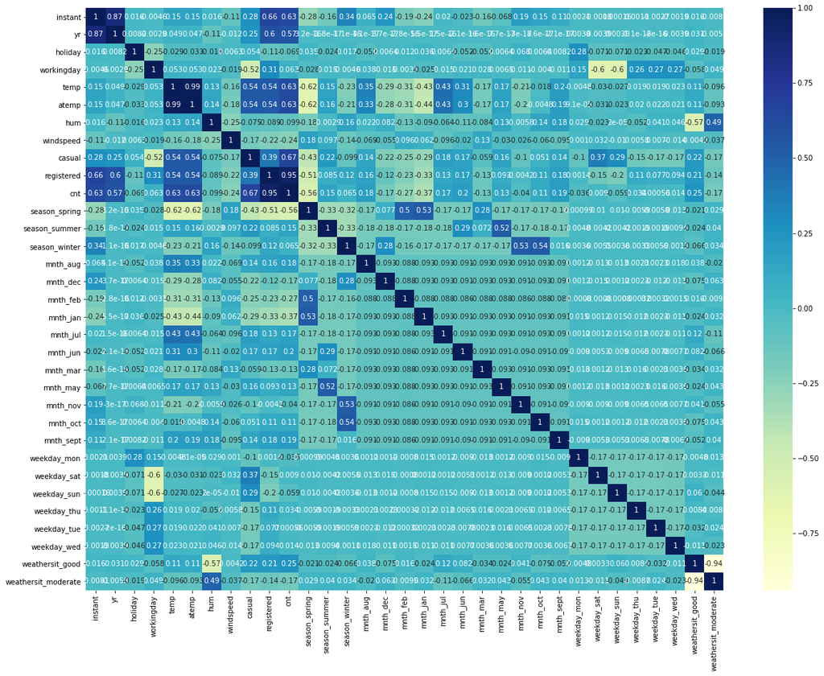

```python
# Let's plot a heatmap
plt.figure(figsize = (20, 15))

sns.heatmap(df.corr(),annot=True, cmap="YlGnBu")
plt.show()
```

**Observation**  
We see that `cnt` seems to the correlated to `temp`, `atemp`, `yr` and `casual` variables. Let's see a pairplot for `cnt` with `temp` and `atemp`.

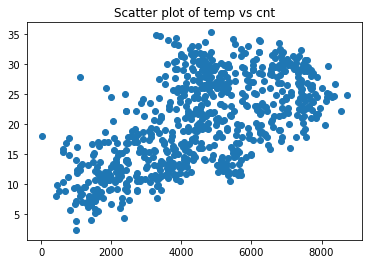

```python
plt.scatter(df.cnt,df.temp)
plt.title("Scatter plot of temp vs cnt")
plt.show()
```

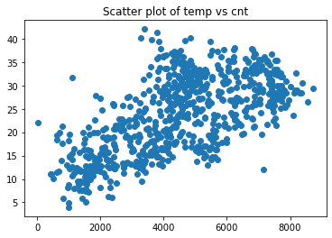

```python
plt.scatter(df.cnt,df.atemp)
plt.title("Scatter plot of temp vs cnt")
plt.show()
```

**Next Step**  
We will split the train test into X as predictor variables and Y as target variables.

```python
### Dividing into X and Y sets for the model building

y_train = df_train.pop('cnt')
X_train = df_train
```

```python
X_train.shape
```

```
(510, 32)
```

**Next Step**  
We will create an instance of Linear Regression model